# Socioeconomics of 2020 Democratic Voters

Joanne Musa

# 1 OBJECTIVE

This analysis integrates four US-based data sets inclusive of information on socioeconomic status during the 2020 election year. The population for this study are 2020 Democratic voters. The economic indicators examined are poverty rates and unemployment rates across US counties. During any presidential election, voter demographics are analyzed in order to create effective campaigns. In turn, trends within socioeconomic variables will be analyzed. The platform used for the data management and analysis is R.

# 2 DATA SOURCES

## 2.1 Data Sets

Education 2015-2019. The education data set contains 3,283 observations and 47 variables. The variables describe geographic location and education levels by year. For this analysis, only data on four specific levels of education for the years 2015-2019 will be used.

Presidential Election 2020. The presidential election data set contains 72,617 observations and 12 variables. The data includes year, geographic location, political party, candidate, and votes. Only data for the year 2020 for the winning party will be extracted from this data set for this analysis.

Unemployment 2020. The unemployment data set contains 290,441 observations and 5 variables. Data on geographical location, employment status and nature, and unemployment rates are inclusive. This study will examine unemployment data only for the most recent year.

Poverty 2019. The poverty data set contains 79,919 observations and 5 variables. This analysis will only use specifically unemployed status for the year 2019 and the associated unemployment rate.

## 2.2 Data Preparation

The primary key across all the data sets is FIPS (Federal Information Processing Standards). NIST developed FIPS to ensure that systems meet security requirement. FIPS also uniquely identifies geographic areas. The number of digits in FIPS codes vary depending on the level of geography. State-level FIPS codes have two digits, county-level FIPS codes have five digits of which the first two are the FIPS code of the state to which the county belongs. The FIPS variable is retained for all four data sets.

Missing data was addressed and managed throughout the data preparation process. Data management, including subsetting, calculating, and collapsing observations, were not hindered due to missing data.

The education data set was filtered to include only data from 2015 - 2019. Additionally, data that represented percents were kept in the data set, while counts were removed. The specific education levels retained in the data set are less than high school diploma, high school diploma, some college, and bachelors or higher. In addition, the variable names were abbreviated from their original form.

For the presidential election data, the first step was to filter the data by the year 2020. Next, all parties other than Democrats and Republicans were removed from the data set. Once the data set was filtered for those parties, the number of votes by county were aggregated by party, which indicated that the Democrats were the winning party. In turn, data related to the Republican party was removed. Lastly, multiple county entries were collapsed by FIPS.

The unemployment data set was first filtered to include only data from 2000 onward. Upon doing so, data from 2020 was identified as the most recent data. In turn, 2020 data was retained and 2000 data was removed. The variable named “value” was changed to “unemp_value”, as the poverty data set also contained a variable named “value”.

The poverty data set was initially filtered by the year 2019 and status that corresponded to unemployed. After subsetting, the data set included “value” which referred to the poverty rates. Lastly, the “value” variable was renamed to “pov_value”.

## 2.3 Data Merge

A left merge in R was used to create one final data set using FIPS as the primary key. This final data set containing all the relevant variables and observations for this study. After merging, additional data management measures were taken to ensure proper visualization and analysis. Types of variable were checked for consistency. Commas were removed from values of some variables. Variable names were changed to facilitate more clear communication. The final data set contains 3,114 observations and 11 variables. At least two of the variables are passive, and are retained as identifiers. Any observations missing most of the data values were removed from the final data set. The FIPS variable was retained as the primary key. Therefore, eight variables in the final data set was used for analysis.

# 3 ANALYSIS I

## 3.1 Unemployment

Economists in the US suggest that unemployment rates below 5% is an indication that the economy is at or close to full capacity. In 2020, unemployment were relatively high possibly due to the COVID shut down. Unemployment rates are listed by county in the data set. Figure A displays the distribution of unemployment rate in 2020 across counties. The distribution is slightly skewed right due to high outliers. The typical unemployment rate is about 6.7% (Table A). The unemployment rates by county vary from 1.7 to 22.5% (Table A). The typical variation from the mean unemployment is about 2.2%.

The average unemployment rate was calculated for each state using the county data. Figure B displays the distribution of unemployment rate by state. The state with the highest average unemployment rate is Hawaii and the state with the lowest average unemployment rate is Nebraska.

```r
# Load data

dataforpart2 = read.csv("https://raw.githubusercontent.com/jmusa3/jmusa/refs/heads/main/project1merged_data.csv", header = TRUE)

data(dataforpart2)

# Create a summary of statistics for Pov_Value
summary_stats <- data.frame(
  Statistic = c("Mean", "Median", "Standard Deviation", "Minimum", "Maximum"),
  Value = c(
    mean(dataforpart2$unemp_value),
    median(dataforpart2$unemp_value),
    sd(dataforpart2$unemp_value),
    min(dataforpart2$unemp_value),
    max(dataforpart2$unemp_value)
  )
)

# Display the summary table using knitr::kable
kable(summary_stats, caption = "Summary Statistics for 2020 Unemployment Rates Across Counties")
```

Summary Statistics for 2020 Unemployment Rates Across Counties

| Statistic | Value |
| --- | --- |
| Mean | 6.713520 |
| Median | 6.500000 |
| Standard Deviation | 2.242111 |
| Minimum | 1.700000 |
| Maximum | 22.500000 |

Table A. Statistical summary of unemployment rates in 2020.

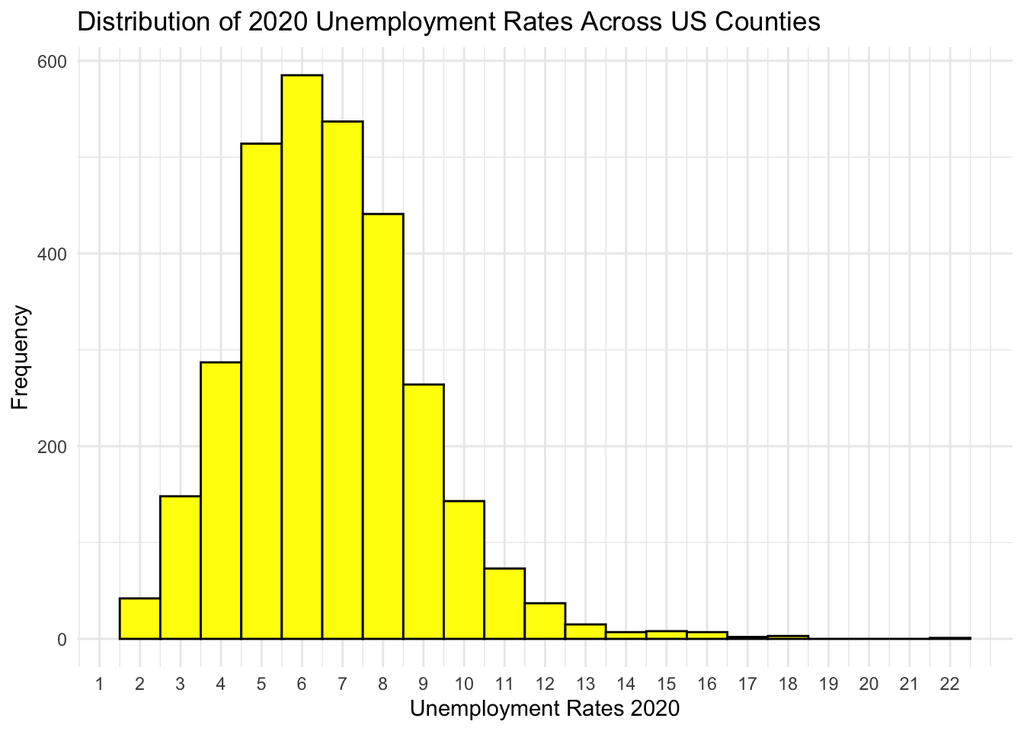

```r
ggplot(dataforpart2, aes(x = unemp_value)) +
  geom_histogram(binwidth = 1, fill = "yellow", color = "black") +
  labs(title = "Distribution of 2020 Unemployment Rates Across US Counties",
       x = "Unemployment Rates 2020",
       y = "Frequency") +
  scale_x_continuous(breaks = seq(0, max(dataforpart2$unemp_value, na.rm = TRUE), by = 1)) +
  theme_minimal()
```

Figure A. Distribution of 2020 unemployment rates across US counties.

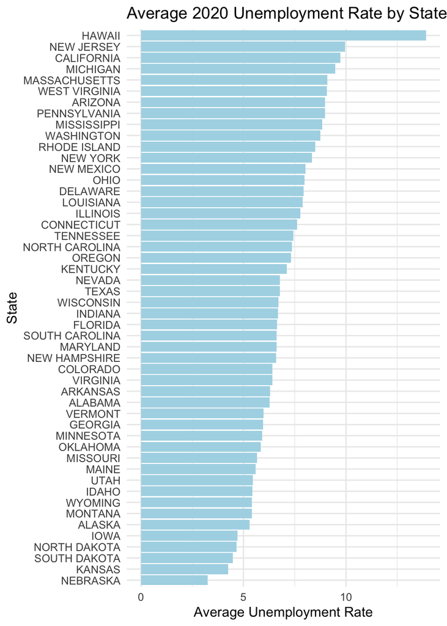

```r
dataforpart2 = read.csv("https://raw.githubusercontent.com/jmusa3/jmusa/refs/heads/main/project1merged_data.csv", header = TRUE)

# AVERAGE UNEMPLOYMNENT RATE BY STATE BAR CHART
# find average unemployment rate by state

avg_unemp_by_state <- dataforpart2 %>%
  group_by(state) %>%
  summarize(avg_unemp_value = mean(unemp_value, na.rm = TRUE))

# Bar plot of average unemployment rate by state
ggplot(avg_unemp_by_state, aes(x = reorder(state, avg_unemp_value), y = avg_unemp_value)) +
  geom_bar(stat = "identity", fill = "lightblue") +
  labs(title = "Average 2020 Unemployment Rate by State",
       x = "State",
       y = "Average Unemployment Rate") +
  theme_minimal() +
  coord_flip() # Optional: flip coordinates for better readability
```

Figure B. Unemployment rate by state.

## 3.2 Poverty

Poverty is a state or condition in which a person or community lacks the financial resources and other essentials for a minimum standard of living. Specifically, the US government defines poverty by a level of annual income equal to three times the amount of money necessary to purchase the minimum quantity of food required for adequate nutrition.

In Figure C, the distribution of 2019 US poverty rates by county is skewed right. The typical poverty rate by counties in 2019 is about 14.5% and a typical deviation of about 5.8% (Table B). There are high outliers which correspond to counties with much higher than average poverty rates. Poverty rates in 2019 varied from 2.7% to 47.7%. Mississippi, Louisiana, and New Mexico have the highest average poverty rates in 2019. New Hampshire, New Jersey, and Rhode Island have the lowest average poverty rates in 2019 (Figure D).

The poverty rates are reported for each county in the data set. The average poverty rate for each state was calculated from the county data. The distribution of 2019 poverty rates by state is displayed in Figure D. Mississippi, Louisiana, and New Mexico have the highest average poverty rates in 2019. New Hampshire, New Jersey, and Rhode Island have the lowest average poverty rates in 2019.

```r
# Load data
data(dataforpart2)

# Create a summary of statistics for Pov_Value
summary_stats <- data.frame(
  Statistic = c("Mean", "Median", "Standard Deviation", "Minimum", "Maximum"),
  Value = c(
    mean(dataforpart2$Pov_Value),
    median(dataforpart2$Pov_Value),
    sd(dataforpart2$Pov_Value),
    min(dataforpart2$Pov_Value),
    max(dataforpart2$Pov_Value)
  )
)

# Display the summary table using knitr::kable
kable(summary_stats, caption = "Summary Statistics for 2019 Poverty Rates Across Counties")
```

Summary Statistics for 2019 Poverty Rates Across Counties

| Statistic | Value |
| --- | --- |
| Mean | 14.458414 |
| Median | 13.400000 |
| Standard Deviation | 5.775829 |
| Minimum | 2.700000 |
| Maximum | 47.700000 |

Table B. Summary statistics for 2019 poverty rates.

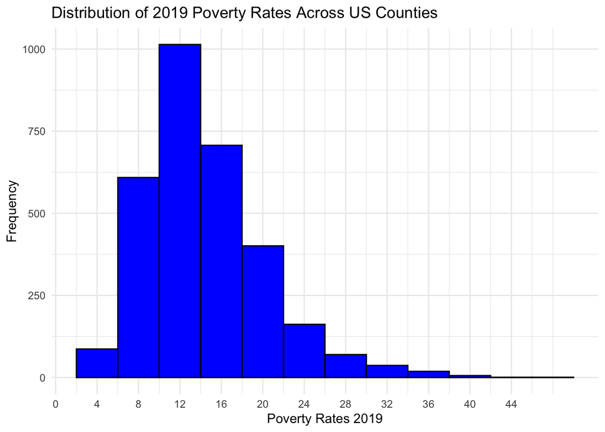

```r
ggplot(dataforpart2, aes(x = Pov_Value)) +
  geom_histogram(binwidth = 4, fill = "blue", color = "black") +
  labs(title = "Distribution of 2019 Poverty Rates Across US Counties",
       x = "Poverty Rates 2019",
       y = "Frequency") +
  scale_x_continuous(breaks = seq(0, max(dataforpart2$Pov_Value, na.rm = TRUE), by = 4)) +
  theme_minimal()
```

Figure C. Distribution of 2019 poverty rates across US counties.

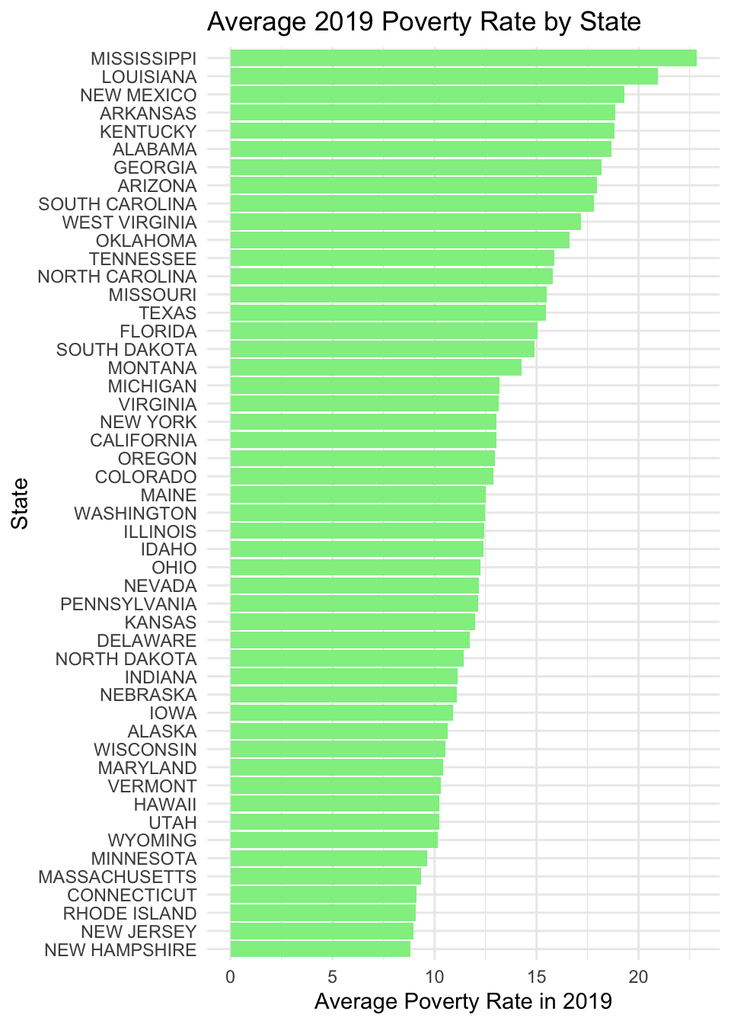

```r
# AVERAGE POVERTY RATE BY STATE BAR CHART
# find average poverty rate by state
avg_povrate_by_state <- dataforpart2 %>%
  group_by(state) %>%
  summarize(avg_povrate = mean(Pov_Value, na.rm = TRUE))

# Bar plot of average poverty rate by state
ggplot(avg_povrate_by_state, aes(x = reorder(state, avg_povrate), y = avg_povrate)) +
  geom_bar(stat = "identity", fill = "lightgreen") +
  labs(title = "Average 2019 Poverty Rate by State",
       x = "State",
       y = "Average Poverty Rate in 2019") +
  theme_minimal() +
  coord_flip() # Optional: flip coordinates for better readability
```

Figure D. Distribution of 2019 poverty rates by state.

## 3.3 Education

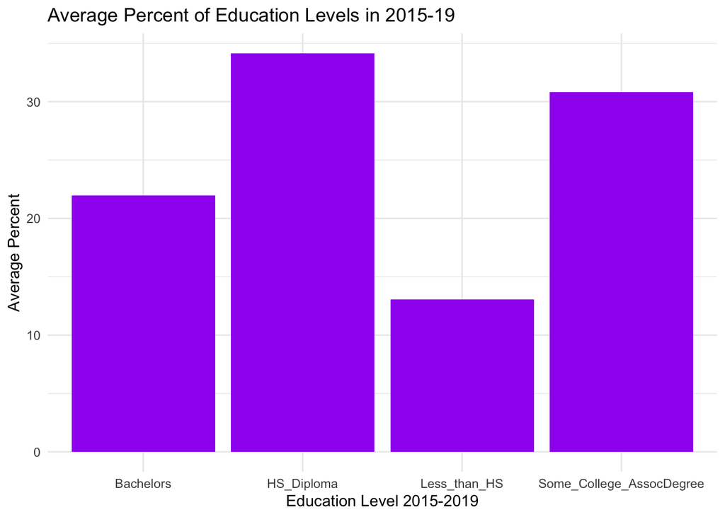

```r
#Bar chart for average of 4 educ levels

# Calculate the average of each variable
averages <- dataforpart2 %>%
  summarise(
   Less_than_HS = mean(Less_than_HS),
    HS_Diploma = mean(HS_Diploma),
    Some_College_AssocDegree = mean(Some_College_AssocDegree),
    Bachelors = mean(Bachelors_or_higher)
  )

# Reshape the data for ggplot
averages_long <- tidyr::pivot_longer(averages, everything(), names_to = "Variable", values_to = "Average")

# Create a bar chart of the averages
ggplot(averages_long, aes(x = Variable, y = Average, fill = Variable)) +
  geom_bar(stat = "identity") +
  labs(title = "Average Percent of Education Levels in 2015-19", x = "Education Level 2015-2019", y = "Average Percent") +
  theme_minimal() +
  theme(legend.position = "none") +
  scale_fill_manual(values = c("purple", "purple", "purple", "purple"))
```

Figure E. Average percent of four levels of education attainment.

# 4 ANALYSIS II

## 4.1 Correlation

Poverty rates and ‘bachelors or higher degree’ education level rates have the strongest negative relationship at -0.486. As rates of bachelors or higher degree attainment increases, rates of poverty decreases. Figure G displays a scatterplot of the relationship between poverty rates and ‘bachelors or higher degree’ education level rates. The relationship appear to have a non-linear form. One county that has 0% ‘bachelors or higher degree’ rate has a relatively low poverty rate of about 7%. Another county that has about a 1-2% ‘bachelors or higher degree’ rate also has a relatively low poverty rate at about 14%. These two data points fall outside of the overall pattern and may be potential outliers.

```r
set1 <- dataforpart2 %>% select(Pov_Value, unemp_value)
set2 <- dataforpart2 %>% select(Less_than_HS, HS_Diploma, Some_College_AssocDegree, Bachelors_or_higher)

cor_matrix <- cor(set1, set2, use = "complete.obs")

print(cor_matrix)
```

```
            Less_than_HS HS_Diploma Some_College_AssocDegree
Pov_Value      0.6291637 0.30349953               -0.2860617
unemp_value    0.2402249 0.06189175               -0.2089141
            Bachelors_or_higher
Pov_Value           -0.48555407
unemp_value         -0.09026264
```

Table C

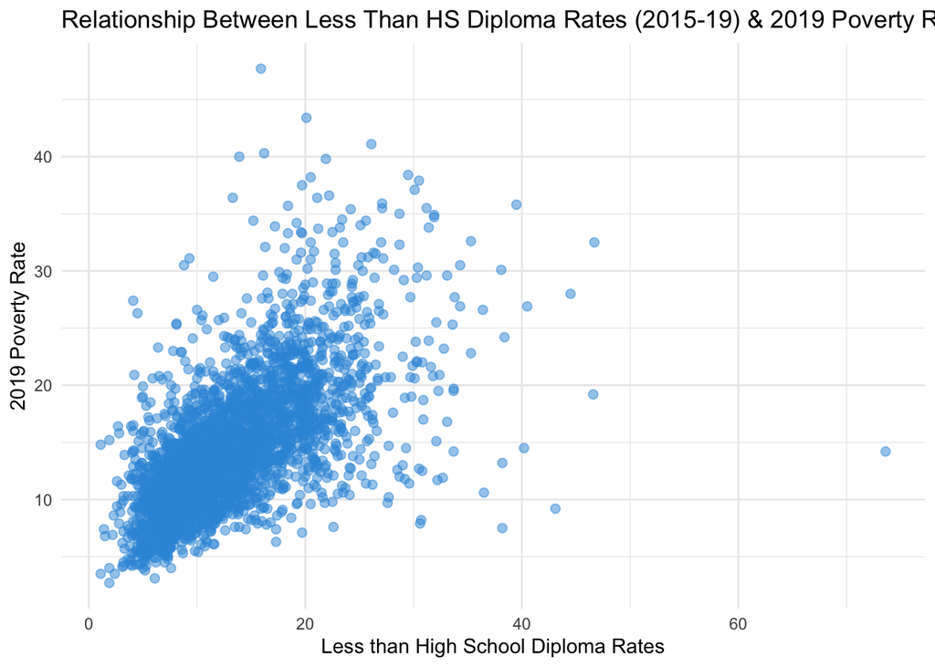

```r
ggplot(dataforpart2, aes(x = Less_than_HS, y = Pov_Value)) +
  geom_point(size = 2, color = "#3498DB", alpha = 0.5) +  # Customize point size
  labs(title = "Relationship Between Less Than HS Diploma Rates (2015-19) & 2019 Poverty Rates Across All Counties ", x = "Less than High School Diploma Rates",
       y = "2019 Poverty Rate") +
  theme_minimal()
```

Figure F. The scatterplot examines the relationship between poverty rates and low education rates 2015-2019.

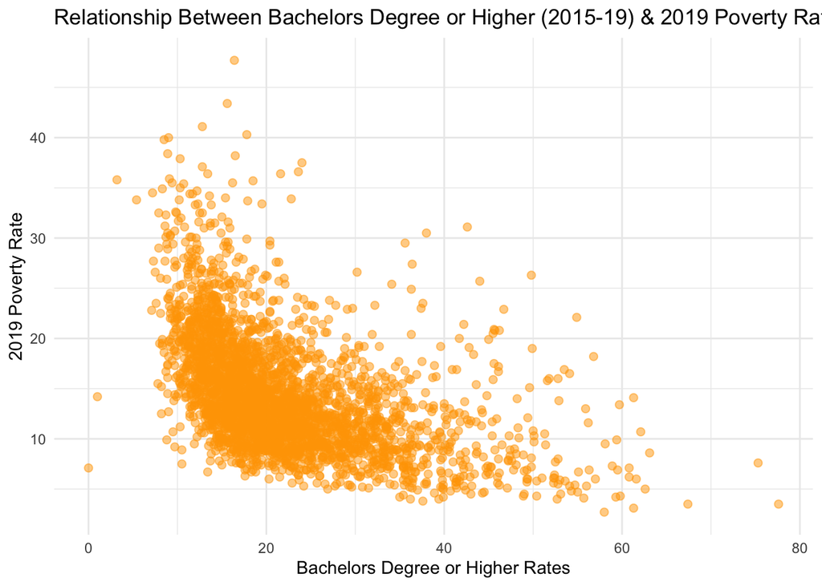

```r
ggplot(dataforpart2, aes(x = Bachelors_or_higher, y = Pov_Value)) +
  geom_point(size = 2, color = "orange", alpha = 0.5) +  # Customize point size
  labs(title = "Relationship Between Bachelors Degree or Higher (2015-19) & 2019 Poverty Rates", x = "Bachelors Degree or Higher Rates",
       y = "2019 Poverty Rate") +
  theme_minimal()
```

Figure G. The scatterplot examining the relationship between poverty rates and higher education rates 2015-19.

## 4.2 Regression

```r
# Linear regression model: Pov_Value as dependent, Less_than_HS as independent
model <- lm(Pov_Value ~ Less_than_HS, data = dataforpart2)

# Print the model summary
summary(model)
```

```
Call:
lm(formula = Pov_Value ~ Less_than_HS, data = dataforpart2)

Residuals:
    Min      1Q  Median      3Q     Max
-35.386  -2.743  -0.454   2.208  31.605

Coefficients:
             Estimate Std. Error t value Pr(>|t|)
(Intercept)   6.86660    0.18639   36.84   <2e-16 ***
Less_than_HS  0.58042    0.01285   45.16   <2e-16 ***
---
Signif. codes:  0 '***' 0.001 '**' 0.01 '*' 0.05 '.' 0.1 ' ' 1

Residual standard error: 4.49 on 3112 degrees of freedom
Multiple R-squared:  0.3958,    Adjusted R-squared:  0.3957
F-statistic:  2039 on 1 and 3112 DF,  p-value: < 2.2e-16
```

Table D. Regression output.

[figure not shown]

```r
# Scatter plot with a regression line
ggplot(dataforpart2, aes(x = Less_than_HS, y = Pov_Value)) +
  geom_point() +
  geom_smooth(method = "lm", se = TRUE, color = "blue") +
  labs(title = "Less than High School Diploma (2015-19) vs Poverty Rate (2020)",
       x = "Less than HS Diploma Rate 2015-19",
       y = "Poverty Rate 2020") +
  theme_minimal()
```

[output not shown]

# 5 CONCLUSION

Voter demographics are analyzed by every presidential campaign. The objective of the campaign is to gain votes for a victory. Strategies for victory are developed using voter data. The voter demographics for the 2020 presidential election was examined in this study based on aggregation of four data sets. Socioeconomic issues were heightened during this election due to the COVID shut down which spawned an economic crisis. Many voters lost their jobs and struggled financially. The 2020 presidential elections saw the highest voter turnout in U.S. election history, including among poor and low-income voters.